# ESTEEM Study: Propensity Score Integrated Power Prior (PSIPP)

Ethan Alt

2023-01-25

## Stan implementation of psipp

We now write the Stan code for the PSIPP We assume a normal linear model where we wish only to borrow from the historical controls.

We store the model in an object called `psipp_model`.

```stan
data {
  int<lower=0> n;                                 // current data sample size
  int<lower=0> n0;                                // historical data sample size
  int<lower=0> nstrata;                           // number of strata
  vector[n] y;                                    // current data outcomes
  vector[n0] y0;                                  // historical data outcomes
  array[n] int<lower=0,upper=1> trt;              // treatment assignment for current data
  array[n] int<lower=1,upper=nstrata> stratum;    // stratum assignment for current data
  array[n0] int<lower=1,upper=nstrata> stratum0;  // stratum assignment for historical data
  vector<lower=0,upper=1>[nstrata] a0;            // power prior parameters
  real mu_mean;                                   // mean hyperparameter for normal prior on mean
  real<lower=0> mu_sd;                            // SD hyperparameter for normal prior on mean
}
transformed data {
  array[n] int trtindx;   // (1 = placebo; 2 = treatment)
  for ( i in 1:n ) {
    trtindx[i] = trt[i] + 1;
  }
}
parameters {
  matrix[nstrata, 2] mu;
  matrix<lower=0>[nstrata, 2] sigma;
}
model {
  // initial priors
  for ( j in 1:2 ) {
    mu[, j] ~ normal(mu_mean, mu_sd);
    sigma[, j] ~ cauchy(0, 1);
  }

  // historical data (power prior)
  for ( i in 1:n0 )
    target += a0[stratum0[i]] * normal_lpdf(y0[i] | mu[ stratum0[i], 1 ], sigma[ stratum0[i], 1 ]);  // only controls

  // likelihood
  for ( i in 1:n )
    target += normal_lpdf(y[i] | mu[ stratum[i], trtindx[i] ], sigma[ stratum[i], trtindx[i] ]);
}

generated quantities {
  vector[nstrata] trteff_stratum = mu[, 2] - mu[, 1];
  real trteff = mean(trteff_stratum);
}
```

## R code for analysis

### Obtaining the data

We can obtain the data directly from GitHub.

```r
library(tidyverse)
library(cmdstanr)
library(bayesplot)
library(posterior)
library(ggthemes)
library(kableExtra)
library(broom)


url <- 'https://raw.githubusercontent.com/ethan-alt/IntroBayesianAnalysis/main/Data'
esteem1 <- read.csv(file.path(url, 'esteem1.csv'))
esteem2 <- read.csv(file.path(url, 'esteem2.csv'))

## Keep only full data
esteem1 <- esteem1[complete.cases(esteem1), ]
esteem2 <- esteem2[complete.cases(esteem2), ]

## Subset for historical controls
esteem1.ctrls <- esteem1 %>% filter(treatment == 'Placebo')

## Declare placebo as reference group
esteem1$treatment <- factor(esteem1$treatment, levels = c('Placebo', '30 mg BID'))
esteem2$treatment <- factor(esteem2$treatment, levels = c('Placebo', '30 mg BID'))

## First few lines of esteem1
head(esteem1)
```

```
##   studyid treatment pasi_pchg bsa_chg dlqi_chg age        smoke prior_sys
## 1       1 30 mg BID     -91.7   -12.0       -7  22    PAST USER         N
## 2       1 30 mg BID     -43.0   -18.3       -5  47 CURRENT USER         Y
## 3       1 30 mg BID     -16.5    -7.4      -12  55 CURRENT USER         Y
## 4       1 30 mg BID     -38.0   -21.9       -7  40 CURRENT USER         Y
## 5       1 30 mg BID     -35.5    -3.0      -13  37 CURRENT USER         N
## 6       1 30 mg BID     -71.0    -1.5       -7  43    PAST USER         Y
##   pasi_bsl bsa_bsl dlqi_bsl    study
## 1     21.3     9.7       14 ESTEEM-I
## 2     18.2    19.5       14 ESTEEM-I
## 3     17.1    19.5       15 ESTEEM-I
## 4     25.1    10.2       13 ESTEEM-I
## 5     29.5    37.3        8 ESTEEM-I
## 6     19.1    35.2       12 ESTEEM-I
```

```r
## First few lines of esteem2
head(esteem2)
```

```
##   studyid treatment pasi_pchg bsa_chg dlqi_chg age        smoke prior_sys
## 1       2 30 mg BID     -19.3    -5.6       -7  55 CURRENT USER         N
## 2       2 30 mg BID     -23.0     4.1       -6  45   NEVER USER         N
## 3       2 30 mg BID     -15.7    -9.7       -7  36   NEVER USER         N
## 4       2 30 mg BID     -29.9     2.8       -3  23 CURRENT USER         Y
## 5       2 30 mg BID     -80.0     3.7      -23  37 CURRENT USER         Y
## 6       2 30 mg BID     -14.7   -28.7        8  26    PAST USER         N
##   pasi_bsl bsa_bsl dlqi_bsl     study
## 1     19.6    27.5       10 ESTEEM-II
## 2     19.0    26.5        8 ESTEEM-II
## 3     23.4    41.3       27 ESTEEM-II
## 4     21.5    33.1       12 ESTEEM-II
## 5     26.0    13.9        2 ESTEEM-II
## 6     18.6    27.7       11 ESTEEM-II
```

```r
## Construct pooled data set
pooled <- rbind(esteem1, esteem2) %>% mutate(studyid = factor(studyid))
```

### Constructing the Stan data

We now construct the Stan data.

#### Estimating the propensity scores

We use the full data to estimate the propensity scores

```r
## Set number of strata
nstrata <- 5

## Estimate propensity score (PS)
ps.formula <- studyid ~ scale(pasi_bsl) + scale(age) + I(scale(age)^2) + smoke + prior_sys
ps.glm     <- glm(ps.formula, family = 'binomial', data = pooled)
ps.glm %>% tidy() %>% kable(digits = 3) %>% kable_styling()
```

| term | estimate | std.error | statistic | p.value |
| --- | --- | --- | --- | --- |
| (Intercept) | -0.446 | 0.129 | -3.452 | 0.001 |
| scale(pasi_bsl) | -0.002 | 0.060 | -0.041 | 0.967 |
| scale(age) | -0.150 | 0.063 | -2.380 | 0.017 |
| I(scale(age)^2) | -0.101 | 0.052 | -1.931 | 0.053 |
| smokeNEVER USER | -0.090 | 0.140 | -0.641 | 0.522 |
| smokePAST USER | -0.242 | 0.156 | -1.552 | 0.121 |
| prior_sysY | -0.150 | 0.121 | -1.238 | 0.216 |

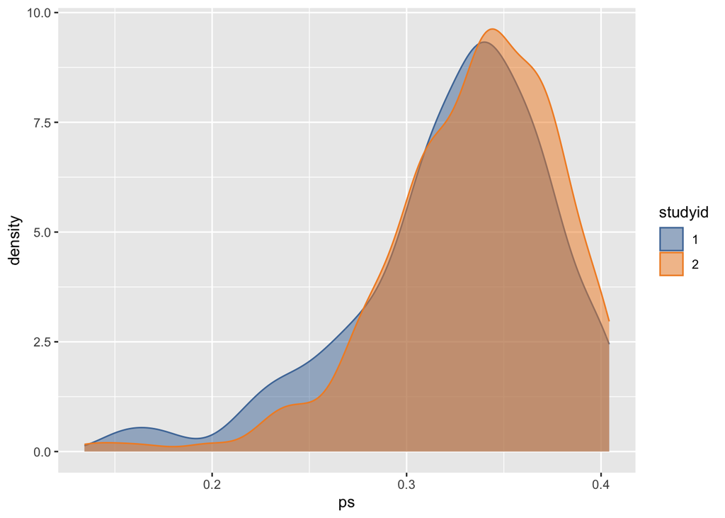

```r
## Obtain fitted PS for all current data and historical controls
pooled.histctrls <- pooled %>%
  mutate(ps = predict(ps.glm, newdata = pooled, type = 'response')) %>% ## PS calculation
  filter(!( studyid == 1 & treatment == '30 mg BID' ))   ## drop treated historical

## Create strata based on propensity scores of CURRENT RCT
##   Note: this code simultaneously "trims" the PS--removes
##   external subjects whose PS is not in the range of the current.
breaks <- pooled.histctrls %>%
  filter(studyid == 2) %>%
  select(ps) %>%
  unlist() %>%
  quantile(probs = seq(0, 1, 1 / nstrata))
breaks[1] <- 0
breaks[nstrata+1] <- 1

pooled.histctrls <- pooled.histctrls %>%
  mutate(stratum = cut(ps, breaks)) %>%   ## define strata. Will be NA if PS not in range of current data
  na.omit                                 ## trimming step

## Plot propensity scores by study ID
ggplot(pooled.histctrls, aes(x = ps, color = studyid, fill = studyid)) +
  geom_density(alpha = 0.5) +
  scale_color_tableau() +
  scale_fill_tableau()
```

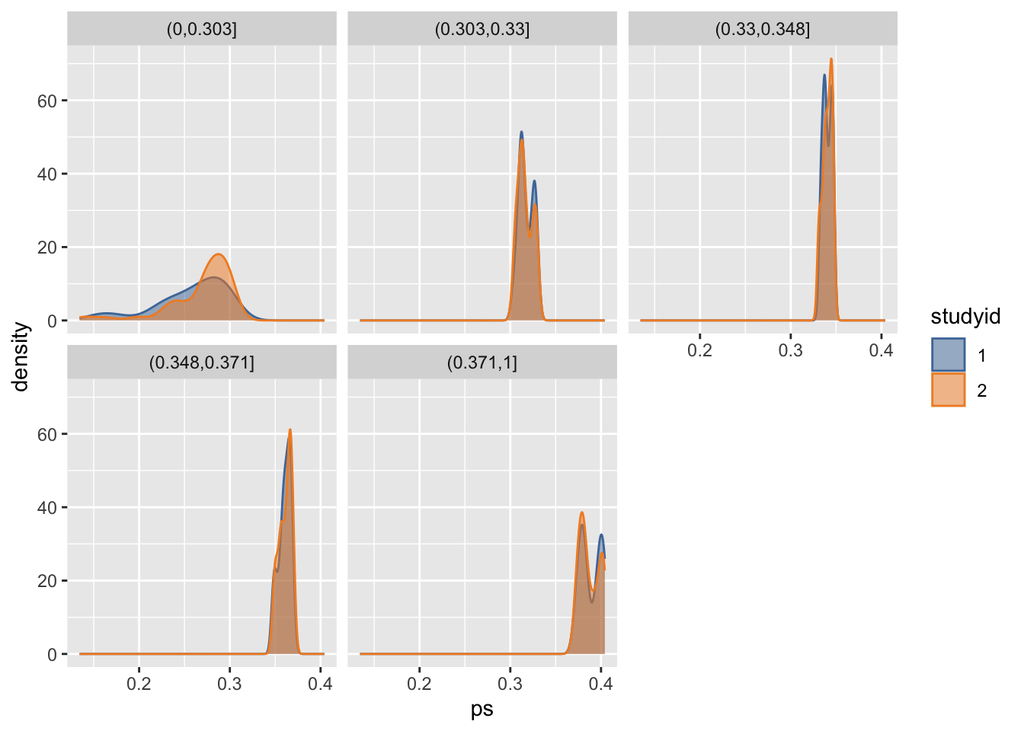

```r
## Plot propensity scores by study ID and stratum
ggplot(pooled.histctrls, aes(x = ps, color = studyid, fill = studyid)) +
  geom_density(alpha = 0.5) +
  scale_color_tableau() +
  scale_fill_tableau() +
  facet_wrap(~stratum)
```

#### Selection of $a_0$

We now determine the $a_{0m}$’s, where $m = 1, \ldots, 5$ indexes the 5 strata.

We first determine the nominal number of historical controls to borrow, $\tilde{n}_{00}$ we desire $\tilde{n_{00} + n_{10}} \approx n_{11}$, where $n_{10}$ is the number of controls in the current data set and $n_{11}$ is the number of treated in the current data set. Thus, we should have
$$\tilde{n}_{00} = \min\{ n_{00}, n_{11} - n_{10} \}$$

```r
n11 <- pooled.histctrls %>% filter(studyid == 2, treatment == '30 mg BID') %>% nrow
n10 <- pooled.histctrls %>% filter(studyid == 2, treatment == 'Placebo') %>% nrow
n00 <- pooled.histctrls %>% filter(studyid == 1, treatment == 'Placebo') %>% nrow
ntilde00 <- min(n00, n11 - n10)
c(n11 = n11, n10 = n10, n00 = n00, ntilde00 = ntilde00)
```

```
##      n11      n10      n00 ntilde00
##      274      137      282      137
```

To compute $a_0$, we first compute the PS overlap for each stratum.

```r
library(overlapping)
```

```r
(stratanames <- levels(pooled.histctrls$stratum))
```

```
## [1] "(0,0.303]"     "(0.303,0.33]"  "(0.33,0.348]"  "(0.348,0.371]"
## [5] "(0.371,1]"
```

```r
ps.overlap <- sapply(
  stratanames, function(s) {
    ## create temporary data set for stratum
    df.stratum <- pooled.histctrls %>%
      filter(stratum == s) %>%
      select(studyid, ps)

    ## get list of propensity scores between current and historical
    pslist <- lapply(1:2, function(i) df.stratum$ps[df.stratum$studyid == i] )

    ## Compute overlap
    overlap(pslist, plot = FALSE)$OV
  }
)
names(ps.overlap) <- stratanames
round(ps.overlap, 3)
```

```
##     (0,0.303]  (0.303,0.33]  (0.33,0.348] (0.348,0.371]     (0.371,1]
##         0.804         0.940         0.898         0.924         0.937
```

Next, we compute the nominal number of patients to borrow, given as

$$\lambda_{0m} = \min\left\{ \frac{r_m}{\sum_{l=1}^5 r_l}
\tilde{n}_{00}, n_{00m} \right\},$$

where $n_{00m} = $ number of observations among historical controls assigned to stratum $m$

```r
## Get number of historical controls assigned to each stratum (n00m)
nstratum.histctrls <- pooled.histctrls %>%
  filter(studyid == 1) %>%
  select(stratum) %>%
  table()

## Get number of current controls assigned ot each stratum (n1m)
nstratum.curctrls <- pooled.histctrls %>%
  filter(studyid == 2, treatment == 'Placebo') %>%
  select(stratum) %>%
  table()

## Get number of current trteated assigned ot each stratum (n1m)
nstratum.curtrts <- pooled.histctrls %>%
  filter(studyid == 2, treatment == '30 mg BID') %>%
  select(stratum) %>%
  table()

## Compute a0 based on ntilde00 and overlap
(w <- ps.overlap / sum(ps.overlap))                ## normalized overlap
```

```
##     (0,0.303]  (0.303,0.33]  (0.33,0.348] (0.348,0.371]     (0.371,1]
##     0.1785808     0.2087717     0.1994443     0.2052197     0.2079835
```

```r
lambda <- pmin( ntilde00 * w, nstratum.histctrls ) ## number of subjects to borrow in each stratum
sum(lambda)                                        ## total number of borrowed controls from historical data
```

```
## [1] 137
```

```r
cbind(
  'n_00m' = nstratum.histctrls,'lambda_0m' = lambda, 'n_10' = nstratum.curctrls
  , 'n_10star' = lambda + nstratum.curctrls, 'n11' = nstratum.curtrts
)
```

```
##               n_00m lambda_0m n_10 n_10star n11
## (0,0.303]        73  24.46557   25 49.46557  58
## (0.303,0.33]     61  28.60172   25 53.60172  57
## (0.33,0.348]     54  27.32387   27 54.32387  55
## (0.348,0.371]    52  28.11510   30 58.11510  52
## (0.371,1]        42  28.49374   30 58.49374  52
```

```r
## Compute power prior parameter
(a0 <- lambda / as.numeric(nstratum.histctrls))
```

```
##     (0,0.303]  (0.303,0.33]  (0.33,0.348] (0.348,0.371]     (0.371,1]
##     0.3351448     0.4688807     0.5059977     0.5406750     0.6784223
```

```r
## Compute total number of controls, treated
c('ctrls' = n10 + sum(lambda), 'trt' = n11)
```

```
## ctrls   trt
##   274   274
```

In this case, the total number of borrowed patients is 137 and the nominal number of patients to borrow is 137`

### Constructing the Stan data

We now use the above to construct the Stan data.

```r
pooled.histctrls$treatment_n <- ifelse(pooled.histctrls$treatment == 'Placebo', 0, 1)
standata <- list(
  'y' = pooled.histctrls %>% filter(studyid == 2) %>% select(pasi_pchg) %>% unlist
  , 'y0' = pooled.histctrls %>% filter(studyid == 1) %>% select(pasi_pchg) %>% unlist
  , 'trt' = pooled.histctrls %>% filter(studyid == 2) %>% select(treatment_n) %>% unlist
  , 'stratum' = pooled.histctrls %>% filter(studyid == 2) %>% select(stratum) %>% unlist %>% as.numeric()
  , 'stratum0' = pooled.histctrls %>% filter(studyid == 1) %>% select(stratum) %>% unlist %>% as.numeric()
  , 'a0'  = a0
  , 'mu_mean' = 0
  , 'mu_sd' = 10
  , 'nstrata' = nstrata
)
standata$n <- length(standata$y)
standata$n0 <- length(standata$y0)
```

Finally, we may call the MCMC sampler.

```r
psipp.smpl <- psipp_model$sample(
  data = standata, iter_warmup = 2000, iter_sampling = 2500, parallel_chains = 4
  , refresh = 0
)
```

```
## Running MCMC with 4 parallel chains...
##
## Chain 1 finished in 1.1 seconds.
## Chain 2 finished in 1.1 seconds.
## Chain 3 finished in 1.1 seconds.
## Chain 4 finished in 1.1 seconds.
##
## All 4 chains finished successfully.
## Mean chain execution time: 1.1 seconds.
## Total execution time: 1.2 seconds.
```

We may summarize the output

```r
psipp.smpl$summary(
  variables = c('trteff_stratum', 'trteff')
  , mean, sd, q = ~quantile2(.x, probs = c(0.025, 0.975))
)
```

```
## # A tibble: 6 × 5
##   variable           mean    sd  q2.5  q97.5
##   <chr>             <dbl> <dbl> <dbl>  <dbl>
## 1 trteff_stratum[1] -40.4  5.46 -51.2 -29.5
## 2 trteff_stratum[2] -29.0  5.24 -39.1 -18.6
## 3 trteff_stratum[3] -33.3  5.25 -43.4 -22.8
## 4 trteff_stratum[4] -16.0  6.13 -28.0  -3.97
## 5 trteff_stratum[5] -22.6  6.14 -34.5 -10.3
## 6 trteff            -28.2  2.53 -33.1 -23.2
```

### Comparison with reference prior

The code for the reference prior may be expressed as

```stan
data {
  int<lower=0> n;                                 // current data sample size
  vector[n] y;                                    // current data outcomes
  array[n] int<lower=0,upper=1> trt;              // treatment assignment for current data
  real mu_mean;                                   // mean hyperparameter for normal prior on mean
  real<lower=0> mu_sd;                            // SD hyperparameter for normal prior on mean
}
transformed data {
  array[n] int trtindx;   // (1 = placebo; 2 = treatment)
  for ( i in 1:n ) {
    trtindx[i] = trt[i] + 1;
  }
}
parameters {
  vector[2] mu;
  vector<lower=0>[2] sigma;
}
model {
  // initial priors
  mu ~ normal(mu_mean, mu_sd);
  sigma ~ cauchy(0, 1);

  // likelihood
  for ( i in 1:n )
    target += normal_lpdf(y[i] | mu[trtindx[i]], sigma[trtindx[i]] );
}
generated quantities {
  real trteff = mu[2] - mu[1];
}
```

```r
ref.smpl <- reference_model$sample(
  data = standata, iter_warmup = 2000, iter_sampling = 2500, parallel_chains = 4
  , refresh = 0
)
```

```
## Running MCMC with 4 parallel chains...
##
## Chain 1 finished in 0.4 seconds.
## Chain 2 finished in 0.3 seconds.
## Chain 3 finished in 0.3 seconds.
## Chain 4 finished in 0.3 seconds.
##
## All 4 chains finished successfully.
## Mean chain execution time: 0.3 seconds.
## Total execution time: 0.5 seconds.
```

```r
ref.smpl$summary()
```

```
## # A tibble: 6 × 10
##   variable    mean  median    sd   mad      q5      q95  rhat ess_bulk ess_tail
##   <chr>      <dbl>   <dbl> <dbl> <dbl>   <dbl>    <dbl> <dbl>    <dbl>    <dbl>
## 1 lp__     -2014.  -2014.   1.43  1.25 -2017.  -2013.    1.00    5447.    7106.
## 2 mu[1]      -10.8   -10.8  3.03  3.04   -15.7    -5.79  1.00   11193.    7678.
## 3 mu[2]      -45.2   -45.2  1.69  1.66   -48.0   -42.4   1.00   11089.    8016.
## 4 sigma[1]    37.3    37.2  2.30  2.28    33.7    41.2   1.00   10660.    7585.
## 5 sigma[2]    28.4    28.4  1.23  1.23    26.5    30.5   1.00   10791.    7845.
## 6 trteff     -34.4   -34.5  3.48  3.57   -40.2   -28.7   1.00   10801.    7565.
```

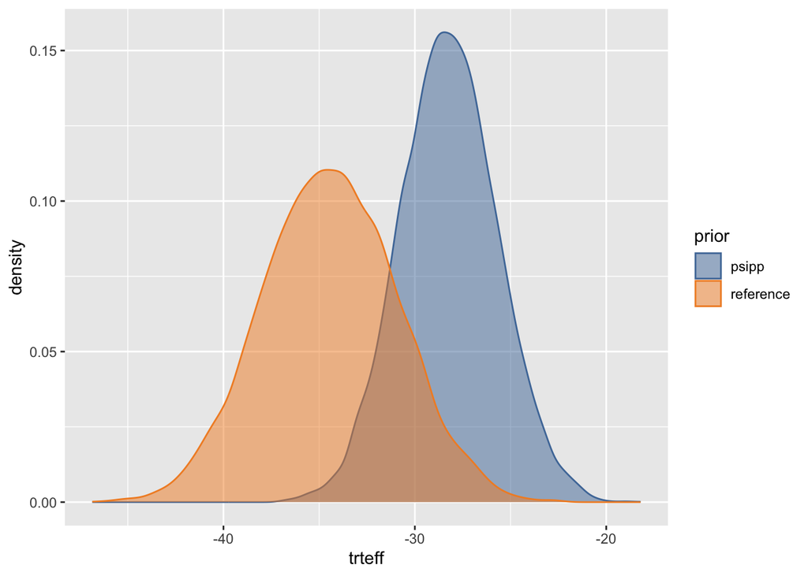

```r
df.psipp <- cbind(prior = 'psipp', psipp.smpl$draws('trteff', format = 'data.frame') )
df.reference <- cbind(prior = 'reference', ref.smpl$draws('trteff', format = 'data.frame') )
plot.df <- rbind(df.psipp, df.reference)
ggplot(
  data = plot.df, aes(x = trteff, color = prior, fill = prior)
) +
  geom_density(alpha = 0.5) +
  scale_color_tableau() +
  scale_fill_tableau()
```